# SAN assignment - Dimensionality reduction

Author : Šimon Gavula

Email : gavulsim@fel.cvut.cz

```python
import numpy as np
import pandas as pd
import matplotlib as mpl
import matplotlib.pyplot as plt
from scipy.sparse.csgraph import shortest_path
from scipy.spatial import voronoi_plot_2d, Voronoi, cKDTree
from sklearn.decomposition import PCA
from sklearn.manifold import MDS, TSNE
from sklearn.model_selection import KFold
from sklearn.preprocessing import StandardScaler
from sklearn.tree import DecisionTreeClassifier
```

## Introduction

The goal of this tutorial is to get familiar with some basic methods for dimensionality reduction, complete you own implementation of the **Isomap algorithm** (in cooperation with *Multidimensional scaling*), experiment with its parameters and compare with other techniques of dimensionality reduction (**PCA**, **t-SNE**).

Your task is to complete prepared Isomap implementation and inspect the mehods behavior. See **all** sections with `# TODO:`. Submit your solution consisting of both this modified notebook file and the exported PDF/HTML document as an archive to the courseware BRUTE upload system for the SAN course. The deadline is specified there.

## Background

The data you will be working with are vector representations of words in a latent (unknown) high-dimensional space. This representation of words, also know as word embedding, differs from standard bag-of-words (BoW, TFIDF, etc.) representations in that the meaning of the words is distributed across all the dimensions. Generally speaking, the word embedding algorithms seek to learn a mapping projecting the original BoW representation (simple word index into a given vocabulary) into a lower-dimensional (but still too high for our case) continuous vector-space, based on their distributional properties observed in some raw text corpus. This distributional semantics approach to word representations is based on the basic idea that linguistic items with similar distributions typically have similar meanings, i.e. words that often appear in a similar context (words that surround them) tend to have similar (vector) representations.

Speciffically, the data you are presented with are vector representations coming from the most popular algorithm for word embedding known as word2vec [1] by Tomas Mikolov (VUT-Brno alumni). *Word2vec* is a (shallow) neural model learning the projection of BoW word representations into a latent space by the means of gradient descend. Your task is to further reduce the dimensionality of the word representations to get a visual insight into what has been learned.

[1]: Tomas Mikolov, Ilya Sutskever, Kai Chen, Greg S Corrado, and Jeff Dean. Distributed representations of words and phrases and their compositionality. In *Advances in neural information processing systems*, pages 3111-3119, 2013.

## Data

You are given 300-dimensional word2vec vector embeddings in the file *data.csv* with corresponding word labels in *labels.txt* for each line. Each of these words comes from one of 10 selected classes of synonyms, which can be recognized (and depicted) w.r.t. labels denoted in the file *colors.csv*

```python
def plot_points(X, labels, colors, title):
    voronoi = Voronoi(X)
    fig, ax = plt.subplots(figsize=(5,4), dpi=128)
    voronoi_plot_2d(voronoi, ax, show_points=False, show_vertices=False)
    ax.scatter(X[:, 0], X[:, 1], c=colors, s=8, cmap=mpl.colormaps["tab10"])
    for point, label in zip(X, labels):
        ax.text(point[0], point[1], label[0], va = "top", ha = "center", fontsize = "xx-small")
    plt.title(title)
    plt.show()
```

```python
def test_classification(X, colors, n_folds=10):
    accuracy = []
    skf = KFold(n_splits=n_folds, shuffle=True, random_state=0)
    for train_idxs, test_idxs in skf.split(X, colors):
      tree_model = DecisionTreeClassifier().fit(X[train_idxs], colors[train_idxs])
      prediction = tree_model.predict(X[test_idxs])
      accuracy.append(np.mean(prediction == colors[test_idxs, 0]))
    return accuracy
```

## Tasks

1. **Load the dataset of 165 words**, each represented as a 300-dimensional vector. Each word is assigned to one of 10 clusters.

```python
#Load the dataset of 165 words
my_data = pd.read_csv("data.csv", header=None).values
my_labels = pd.read_csv("labels.txt", header=None).values
my_colors = pd.read_csv("colors.csv", header=None).values
```

The data is in the matrix `mydata`, cluster assignment in `mycolors` and the actual words (useful for visualization) in `mylabels`. You can plot the data by using only the first 2 dimensions.

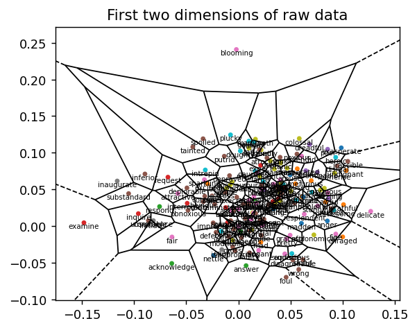

```python
plot_points(my_data[:, [0,1]], my_labels, my_colors, title="First two dimensions of raw data")
```

2. **Implement ISO-MAP dimensionality reduction procedure**.
- Use *k*-NN method to construct the neighborhood graph (sparse matrix).
  - For simplicity, you can use `cKDTree` method available in `sklearn` package.
- Compute shortest-paths (geodesic) matrix using your favourite algorithm.
  - Tip: you can use `shortest_path` method from scipy.
- Project the geodesic distance matrix into 2D space with (Classical) Multidimensional Scaling (`MDS` method from sklearn).
- Challenge: you may simply use PCA to do the same, but be careful to account for a proper normalization (centering) of the geodesic (kernel) matrix (see Kernel PCA for details).

An expected result (for *k* = 5) should look similar (not necessarily exactly the same) to following

[figure not shown]

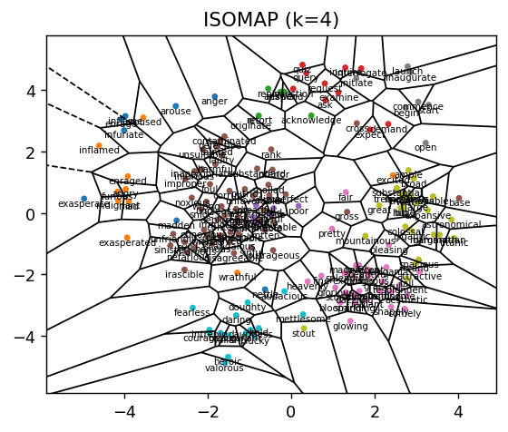

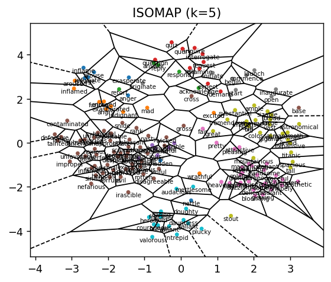

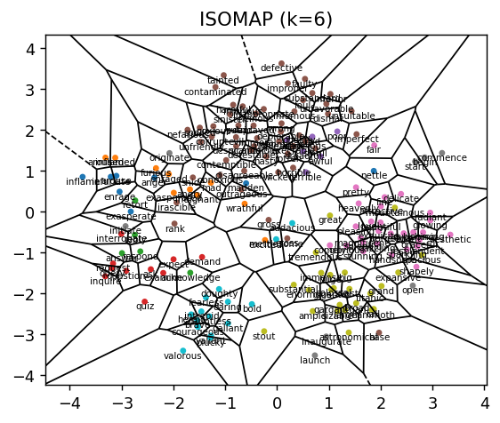

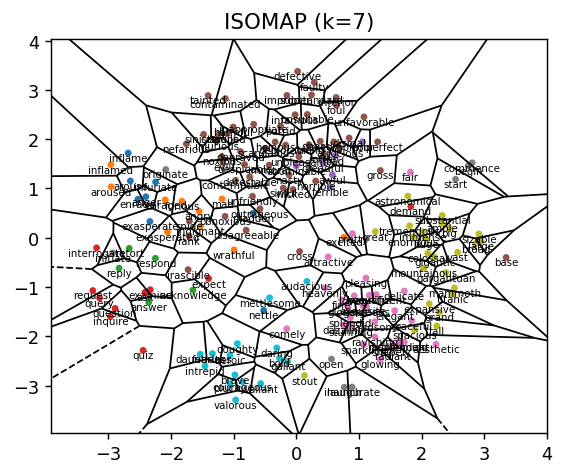

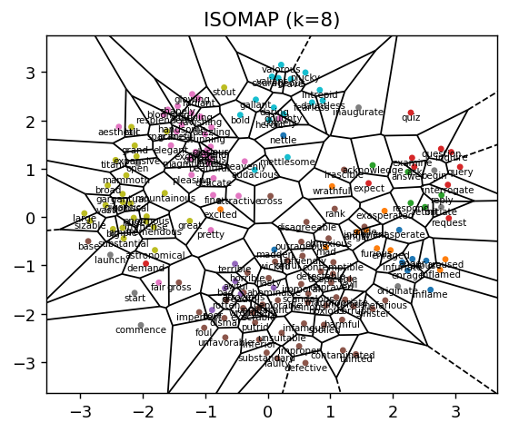

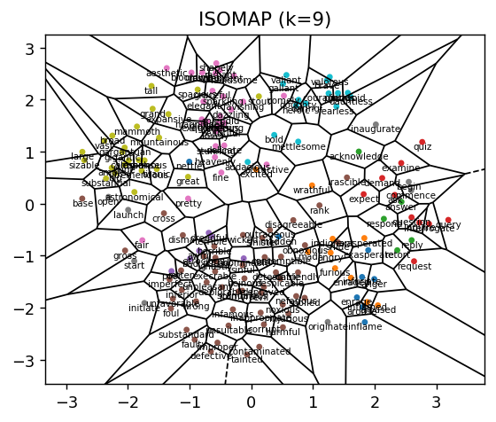

```python
import networkx as nx

def construct_neighbours_graph(n, distances, indices):
    # Init adjacency matrix that represents graph of neighbours
    adj_matrix = np.full((n, n), np.inf)

    # Fill the adjacency matrix
    for curr_idx in range(n):
        curr_distances = distances[curr_idx]
        curr_indices = indices[curr_idx]
        for i, curr_ind in enumerate(curr_indices):
            curr_dist = curr_distances[i]
            adj_matrix[curr_idx][curr_ind] = curr_dist

    return adj_matrix


def isomap(data, k):
    """
    Your function computing the ISOMAP embedding for data.

    :param data: numpy array (m, d) where m is number of samples and d is the dimension of input space
    :param k: number of neighbours to consider for constructing the neighborhood graph
    :return: data embedded into R^2 acc. to the ISOMAP algorithm
    """

    n, m = data.shape

    #1.Determine the neighbors of each point (k-NN)
    tree = cKDTree(data)
    distances, indices = tree.query(data, k=k+1)

    #2.Construct the neighborhood graph.
    #Each point is connected to other if it is a K nearest neighbor.
    #Edge length equal to Euclidean distance.
    graph_adj_matrix = construct_neighbours_graph(n , distances, indices)

    #3.Compute the shortest path between two nodes. (Floyd-Warshall algorithm)
    D = shortest_path(graph_adj_matrix, directed=False)

    # Check if graph is connected
    G = nx.from_numpy_array(graph_adj_matrix)
    is_connected = nx.is_connected(G)

    #4.(classical) multidimensional scaling
    mds = MDS(dissimilarity='precomputed', random_state=0, n_init=4)
    projection = mds.fit_transform(D)

    return projection, is_connected

for k in range(4, 10):
    projection_isomap, _ = isomap(my_data, k=k)
    plot_points(projection_isomap, my_labels, my_colors, title=f"ISOMAP (k={k})")
```

3. **Visually compare PCA, ISOMAP and t-SNE** by plotting the word2vec data, embedded into 2D using the `Plotpoints` function. Try finding the optimal *k* value for ISOMAP's nearest neighbour.

```python
from sklearn.manifold import trustworthiness

best_k = None
best_tw = -1

for k in range(4, 10):
    projection_isomap, is_graph_connected = isomap(my_data, k=k)
    if is_graph_connected == False:
        continue
    tw = trustworthiness(my_data, projection_isomap, n_neighbors=k)
    print(f"K: {k} with trustworthness: {tw}")

    # Store the best k
    if tw > best_tw:
        best_tw = tw
        best_k = k

print("\nBest k =", best_k, "with trustworthiness =", best_tw)
```

```
K: 4 with trustworthness: 0.8836440110888061
K: 5 with trustworthness: 0.8859602393360355
K: 6 with trustworthness: 0.8542011757445841
K: 7 with trustworthness: 0.8732445044133356
K: 8 with trustworthness: 0.8614356681569797
K: 9 with trustworthness: 0.8675630476954981

Best k = 5 with trustworthiness = 0.8859602393360355
```

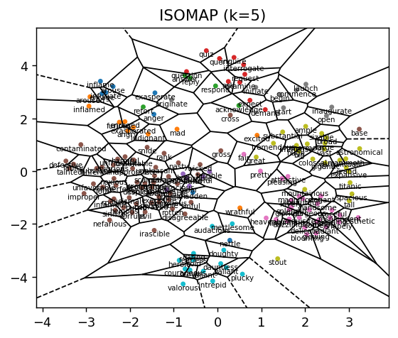

```python
projection_isomap, is_graph_connected = isomap(my_data, k=5)
plot_points(projection_isomap, my_labels, my_colors, title=f"ISOMAP (k={5})")
```

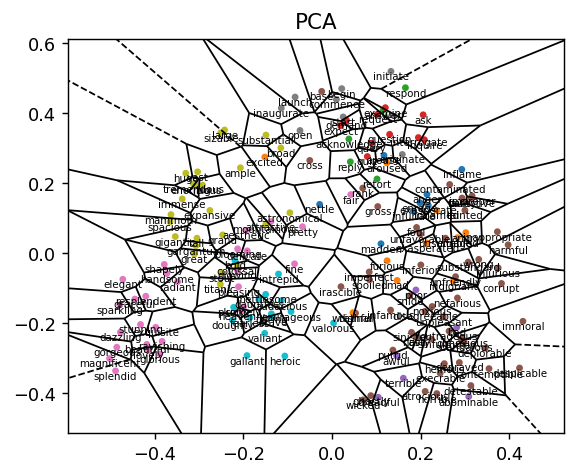

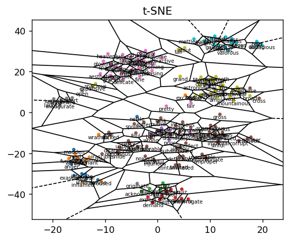

```python
#Principal component analysis
scaled_data = StandardScaler().fit_transform(my_data)
projection_pca = PCA(2).fit_transform(my_data)
plot_points(projection_pca[:, [0, 1]], my_labels, my_colors, title="PCA")

#t-SNE (T-Distributed Stochastic Neighbor Embedding)
projection_tsne = TSNE(n_components=2, perplexity=10, init="random", learning_rate="auto").fit_transform(my_data)
plot_points(projection_tsne, my_labels, my_colors, title="t-SNE")
```

### **Selecting best k**

To choose the optimal value of k for ISOMAP, I used trustworthiness, which measures how well local neighborhoods are preserved after reducing the data to a lower dimension. The best result was achieved with k = 5, which gave a trustworthiness of 0.885.

### **Comparing graphs**

t-SNE produced very clearly separated clusters. ISOMAP also grouped data together, but not as clearly as t-SNE. PCA formed some clusters, but many points overlapped with each other.

4. **Observe the effect of dimensionality reduction on a classiffication algorithm**. The supporting code in a function `test_classification` performs training and testing of classification trees and gives the classification accuracy (percentage of correctly classified samples) on individual cross-validation test splits as its result. Compare the accuracy of prediction on plain data, PCA, ISOMAP and t-SNE.

```python
#classify ISOMAP
acc_isomap = test_classification(projection_isomap, my_colors, 50)

#classify PCA
acc_pca = test_classification(projection_pca, my_colors, 50)

#classify t-SNE
acc_tsne = test_classification(projection_tsne, my_colors, 50)

#PLOT results
print(f"ISOMAP ACC: {np.mean(acc_isomap):>10,.3f}")
print(f"PCA ACC: {np.mean(acc_pca):>13,.3f}")
print(f"t-SNE ACC: {np.mean(acc_tsne):>11,.3f}")
```

```
ISOMAP ACC:      0.755
PCA ACC:         0.567
t-SNE ACC:       0.763
```

**Your comment.** What did you observe?

### **Comparing results**

- Classification with t-SNE produced the best accuracy because it keeps similar points close together when reducing the data. It forms clear clusters, so the classes are easier to separate.
- Classification with ISOMAP produced a middle-level accuracy. It preserves some important structure of the data, but not as effectively as t-SNE.
- Classification with PCA produced the worst accuracy because, although it forms some clusters, many data points still overlap with each other.

## Feedback

Was some part of the notebook unclear, would any topic need more attention during the tutorials? If you want to leave us feedback on the assignment, we would be happy to hear it. Here is your space: